# STATS769 Lab05

Xuan Fang

9/6/2020

# Task 1

In this task, we need to communicate with a web server. We send a request and receive a response, and then we unpack the response with the `content()` function. The format of the body is HTML.

```r
## GET a web page
USstate <- httr::GET("https://en.wikipedia.org/wiki/List_of_U.S._state_and_territory_abbreviations")

## The header contains information about the format of the body: HTML
headers(USstate)$`content-type`
```

```
## [1] "text/html; charset=UTF-8"
```

```r
## Unpacking the response
USstate.co <- content(USstate)
```

# Task 2

In this task, we need to extract the rows that give information about states. We use `xml2::xml_find_all()` and XPath expressions to extract the `<tr>` elements within which the second `<td>` element contains the text State.

```r
USstate_tr <- xml2::xml_find_all(USstate.co, "//tr[td[2]='State']")
```

# Task 3

First, we need to extract the state name. For the rows found in the previous task, we extract the title attribute from the `<a>` element within the first `<td>` element (the state name).

```r
anames <- xml_text(xml2::xml_find_all(USstate_tr, ".//td[1]/a/@title"))[1:4]
```

Second, we need to extract the state abbreviation. We extract the sixth `td` element (the state abbreviation) and make them into lower cases.

```r
acodes <- tolower(xml2::xml_text(xml2::xml_find_all(USstate_tr, ".//td[6]"))[1:4])
```

# Task 4: Extract CSV files

First, we generate four URLs that correspond to the four state abbreviations.

```r
urls <- sprintf("https://covidtracking.com/api/v1/states/%s/daily.csv", acodes)
##  use format %s for character objects
```

Then, we use read.csv() to read the four URLs and combine them into a single data frame.

```r
csvData <- do.call(rbind, lapply(urls, read.csv))
```

Have a look at the dimensions of the data frame

```r
dim(csvData)
```

```
## [1] 745  54
```

# Task 5: Extract HTML tables

First, we generate four URLs that correspond to the four state names.

```r
urls.2 <- sprintf("https://covidtracking.com/data/state/%s/history", anames)
```

Second, we use `httr::GET()` to download the pages and retrieve the contents of those four response.

```r
pages <- lapply(lapply(urls.2, httr::GET), content)
```

Then, we use `rvest::html_table()` to extract the table of COVID data from each page and combine them into a single data frame:

```r
htmlData <- do.call(rbind, sapply(pages, rvest::html_table))
```

Have a look at the dimensions of the data frame extracting from the CSV files and HTML tables. They are similar except there are fewer columns in the HTML tables.

```r
dim(csvData)
```

```
## [1] 745  54
```

```r
dim(htmlData)
```

```
## [1] 745   8
```

# Task 6: Query API with JSON result

First, we generate four URLs that correspond to the four state abbreviations.

```r
urls.3 <- sprintf("https://api.covidtracking.com/v1/states/%s/daily.json", acodes)
```

Second, we use `httr::GET()` to download JSON data and retrieve the contents of those four response as text.

```r
jsonResult <- lapply(lapply(urls.3, httr::GET), content, as="text")
```

```
## No encoding supplied: defaulting to UTF-8.
## No encoding supplied: defaulting to UTF-8.
## No encoding supplied: defaulting to UTF-8.
## No encoding supplied: defaulting to UTF-8.
```

Then, we use `jsonlite::fromJSON` to convert JSON data to R objects and combine them into a single data frame.

```r
apiData <- do.call(rbind, lapply(jsonResult, fromJSON))
```

Have a look at the dimensions of the data frame extracting from the CSV files and JSON files:

```r
dim(csvData)
```

```
## [1] 745  54
```

```r
dim(apiData)
```

```
## [1] 745  54
```

The first 6 rows & 6 columns:

```r
head(csvData)[, 1:6]
```

```
##       date state positive negative pending hospitalizedCurrently
## 1 20200907    AL   132973   855022      NA                   858
## 2 20200906    AL   132314   851994      NA                   841
## 3 20200905    AL   131803   846170      NA                   818
## 4 20200904    AL   130393   840020      NA                   880
## 5 20200903    AL   129285   836689      NA                   872
## 6 20200902    AL   128239   835994      NA                   959
```

```r
head(apiData)[, 1:6]
```

```
##       date state positive negative pending hospitalizedCurrently
## 1 20200907    AL   132973   855022      NA                   858
## 2 20200906    AL   132314   851994      NA                   841
## 3 20200905    AL   131803   846170      NA                   818
## 4 20200904    AL   130393   840020      NA                   880
## 5 20200903    AL   129285   836689      NA                   872
## 6 20200902    AL   128239   835994      NA                   959
```

The last 6 rows & 6 columns:

```r
tail(csvData)[, 1:6]
```

```
##         date state positive negative pending hospitalizedCurrently
## 740 20200311    AR        0       12      14                    NA
## 741 20200310    AR        0       12       3                    NA
## 742 20200309    AR        0       12       0                    NA
## 743 20200308    AR        0        6       0                    NA
## 744 20200307    AR        0        6       0                    NA
## 745 20200306    AR        0        6       0                    NA
```

```r
tail(apiData)[, 1:6]
```

```
##         date state positive negative pending hospitalizedCurrently
## 740 20200311    AR        0       12      14                    NA
## 741 20200310    AR        0       12       3                    NA
## 742 20200309    AR        0       12       0                    NA
## 743 20200308    AR        0        6       0                    NA
## 744 20200307    AR        0        6       0                    NA
## 745 20200306    AR        0        6       0                    NA
```

They are identical.

# Task 7

data preparation:

```r
## Specify the `date` variables as the appropriate class.
csvData$date <- as.Date(as.character(csvData$date), format = "%Y%m%d")
AL.df <- subset(csvData, state=="AL", select = c("date","state", "deathIncrease"))
AK.df <- subset(csvData, state=="AK", select = c("date","state", "deathIncrease"))
AZ.df <- subset(csvData, state=="AZ", select = c("date","state", "deathIncrease"))
AR.df <- subset(csvData, state=="AR", select = c("date","state", "deathIncrease"))
```

The plot:

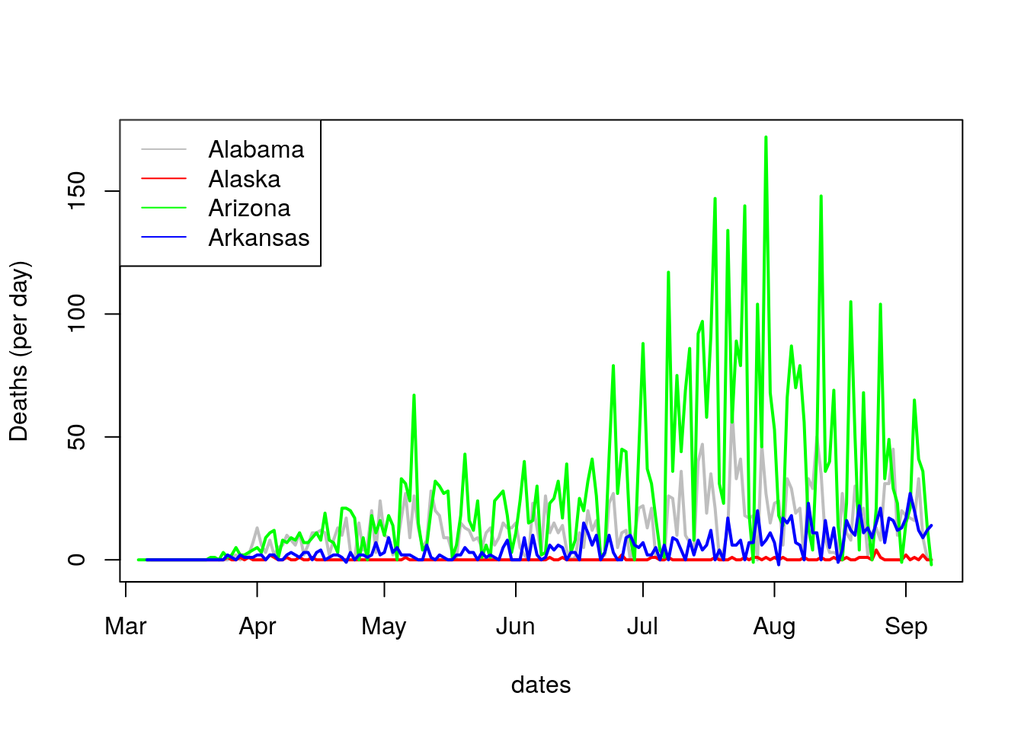

```r
plot(deathIncrease~date, data=AL.df, type = "l", col = "grey", lwd = 2,
     ylim = range(AZ.df$deathIncrease), ylab = "Deaths (per day)", xlab = "dates")
lines(deathIncrease~date, data=AK.df, type = "l", col = "red", lwd = 2)
lines(deathIncrease~date, data=AZ.df, type = "l", col = "green", lwd = 2)
lines(deathIncrease~date, data=AR.df, type = "l", col = "blue", lwd = 2)
legend("topleft", c("Alabama","Alaska", "Arizona", "Arkansas"),
       col=c("grey", "red", "green", "blue"), lty = 1)
```

## Commentary:

- The new death stayed at a low level (basically zero cases at most of the days) in Alaska state from March to September.
- In contrast, the new death stayed at the highest level in Arizona state than the other three states, fluctuating from 0 to around 170. There was an increasing trend from March to August, and a decreasing trend afterward.
- The pattern of the trend in Alabama state was similar to that of Arizona state, but the level of new death is relatively lower, fluctuating from 0 to around 60.
- The new death in Arkansas state was relatively stable from March to June, but had an increasing trend afterward, which reached the maximum 27 at the end of the August.

# Conclusion

- We make use of the Wikipedia page on U.S. state and territory abbreviations.
- We get daily COVID data for four US States: Alabama, Alaska, Arizona, and Arkansas. The data from the The COVID Tracking Project came in three different formats: CSV files, HTML tables, and JSON files. Each format required a different approach to read the data into R, but the data were essentially the same from each source.
- We explored the trend for the new death cases per day for each state. We found that:
1. The new death stayed at the highest level in Arizona state than the other three states, fluctuating from 0 to around 170;
2. The pattern of the trend in Alabama state was similar to that of Arizona state, an increasing trend from March to August, and a decreasing trend afterward. But the level of new death is relatively lower, fluctuating from 0 to around 60;
3. The new death in Arkansas state was relatively stable from March to June, but had an increasing trend afterward, which reached the maximum 27 at the end of the August;
4. The new death stayed at a low level (basically zero cases at most of the days) in Alaska state from March to September.